# Distributions, and the Summaries That Hide Them

Four hundred House districts drawn four ways, and an average that describes almost nothing

Democracy’s Data

Last updated September 13, 2026 at 10:53a EDT

The American House district, you will read, is a fifty-fifty proposition: the average district splits its vote almost evenly between the parties. The average is real. In the 2024 election, the Democratic share of the two-party vote across the 397 contested races had a mean — the ordinary average, every share added up and divided by 397 — of **49.8%** and a median — the middle value, the 199th share once all 397 are sorted, with as many districts above it as below — of **49.6%**. The two agree to within 0.20 of a point. So is the typical district a coin flip?

The question matters because summaries are how citizens meet data. Nobody hands you 397 numbers; they hand you one, and the one number decides what you believe about whether your own vote is contested. This brief draws the same column four ways: a box, a histogram, a cumulative curve, and a stack of years. The same mean, it turns out, can sit on top of opposite electorates.

## The test

The data is the Democratic share of the two-party vote — the votes cast for the Democrat and the Republican, with any other candidate left out — in every contested U.S. House race from 1946 to 2024. The series is two sources joined end to end at a year: the political scientist Gary Jacobson’s file of House results from 1946 to 2014, which circulates among researchers and has no public address, and for 2016 onward the Clerk of the House’s *Statistics of the Congressional Election*, the official tally the Clerk publishes after every election from what each state certifies. Both are read through this book’s house-competition chapter, which assembles them and documents its repairs; the figures here read that assembled file rather than rebuilding it.

The question needs this source because it is about every district at once. A summary hides its distribution only when you hold the whole distribution. House returns are the one record with a number for every district in every election: complete and official rather than sampled, for the reasons this cluster’s chapter on election returns lays out. The test itself is simple: compute the standard summaries, then draw the actual 397 numbers several ways and see which claims survive.

## The data

One row of `districts.csv` is one House race in one election year. A second table, `by_year.csv`, carries one row per election with the summaries already computed. The columns of the district file, by name:

| Column | What it holds | Measurement |
| --- | --- | --- |
| year | the election year | discrete, 1946 to 2024 |
| stcd | a state-district code — the race’s identifier | categorical, one per race |
| dv | the Democratic share of the two-party vote, 0 to 100 | continuous |
| uncontested | whether only one candidate stood | dichotomous |

`dv` is a **share of the two-party vote**, not a share of all votes and not a margin. A district at 50 split evenly between the two major parties; a district at 70 gave the Democrat seven of every ten major-party votes. Four rows of 2024, from the two ends of the column:

| District code | Democratic share | What it means |
| --- | --- | --- |
| 2004 | 88.7% | the most Democratic contested seat |
| 1005 | 85.7% | the second most |
| 4201 | 19.9% | the second least |
| 2703 | 19.6% | the least Democratic contested seat |

The cleaning decision that matters most is an absence. 38 of the 435 seats in 2024 were uncontested — only one major-party candidate stood — so there is no second party and no share to compute. In those rows `dv` is missing, and those seats are not among the 397 drawn below. They are also, by definition, the least competitive seats in the country. Every figure in this brief is therefore drawn on a set with the extreme already removed, a deletion that is patterned rather than random — the ordinary condition of a computed variable.

Here are the summaries of the 397 that remain:

| Summary | Value |
| --- | --- |
| Mean | 49.8% |
| Median | 49.6% |
| Standard deviation | 15.7 |
| 25th percentile | 36.4% |
| 75th percentile | 62.0% |
| Within 5 points of even | 16.9% of races |
| Within 10 points of even | 37.3% of races |

Two of those rows need a word. The standard deviation is a measure of spread: roughly, how far a typical district sits from the mean, so a bigger number means the shares are more scattered. The 25th and 75th percentiles are the values a quarter and three quarters of the way up the sorted list, so half of all districts fall between them. Read the table on its own and a picture assembles itself: a distribution — the whole set of 397 shares and how they are spread along the line from 0 to 100 — centred a shade under even, spread about fifteen points either way, with half the districts between 36.4 and 62.0. It is the picture a well-behaved bell would produce — one hump, symmetric, most values crowded near the middle — and every number in the table is correct.

> **Before you read on, commit to a number.** On the evidence above, **how many of the 397 districts do you expect to sit within five points of even?** Write it down. The table gives you everything you need to guess, and the guess is the point.

## What it says about democracy

**A box says one thing.** Start with the form the summary table implies.

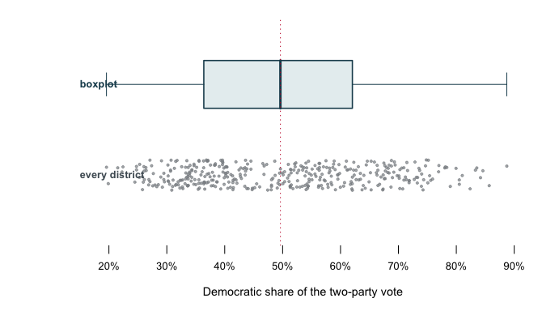

**Figure 1. The same 397 numbers, twice.** A boxplot above — a box spanning the middle half of the districts, from the 25th to the 75th percentile, a bar at the median, and whiskers reaching out to the extremes — and below it the districts themselves, one dot each, jittered — nudged a little up or down at random — so they do not stack on one line. This paired form fits the question because the argument is that the second row contradicts the first, and only one shared axis makes that visible. Hover any point for its district; the dashed line carries the median down from the box.

The boxplot is not wrong: every mark on it is a correct summary of the numbers below it. But the dashed line falls through a **thin patch** in the strip. The box has quietly asserted that the middle of the data is where the data is densest, and in this variable that is false.

**A histogram says another.**

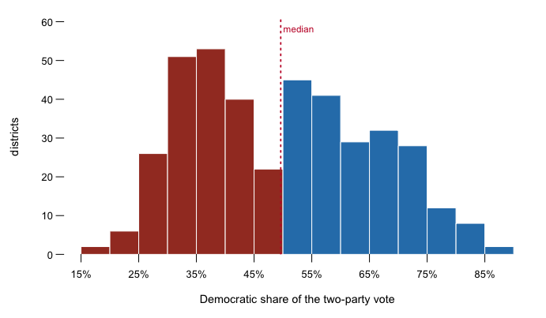

**Figure 2. The same numbers again, as a histogram.** The axis is cut into equal stretches called bins, and each bar counts the districts whose share falls inside one; the control sets the bin width, and nothing else changes. At five points the shape is unmistakable and it is not a bell — it is **two hills with a valley between them**, and the median sits in the valley. There are 22 districts in the five points below even, against 40 in the five points below that and 45 in the five points above. Those two middle bins are the answer to the prompt: 22 + 45 = 67 districts within five points of even, which out of 397 is 16.9%.

Now widen the bins to twelve or fifteen. The valley closes, the hills merge, and the picture becomes the single well-behaved hill the summary table implied. **No number changed.** The only thing that changed is a parameter nobody is obliged to report, and a histogram published without its bin width is an argument with a step missing. The two peaks sit near 35.6% and 55.5%, and a district at either peak is a seat one party wins comfortably. The modal American House district — the most common kind — is safe, and there are two kinds of it.

**A cumulative curve answers the question you asked.** A histogram is a good way to see a shape and a bad way to answer *how many*. The opening question, how many districts are close to even, is a counting question, and there is a form that answers it exactly.

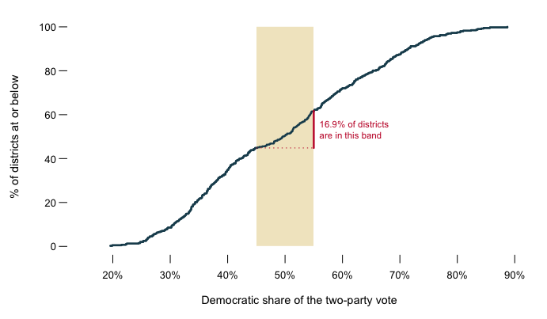

**Figure 3. The same numbers as a cumulative curve.** For any share on the horizontal axis, the curve gives the percentage of districts at or below it. Set the band and the figure reads the count off the curve directly: at ±5 points it is **16.9%** of contested districts, and at ±10 points **37.3%**.

Compare that with the number you wrote down. The summary table said the middle half of districts ran from 36.4 to 62.0, a spread of 25.7 points, and it is easy to read that as *the middle is crowded*. It is not. The curve climbs steeply on both flanks and **flattens through the middle**, and a flat stretch on a cumulative curve is exactly what an empty region looks like.

**Five elections, stacked.** The valley is often explained as something recent, a product of the last two redistricting cycles. One year cannot test that; a stack of years can — five elections drawn the same way on the same axis, one above another, so that the eye compares shapes rather than reading numbers.

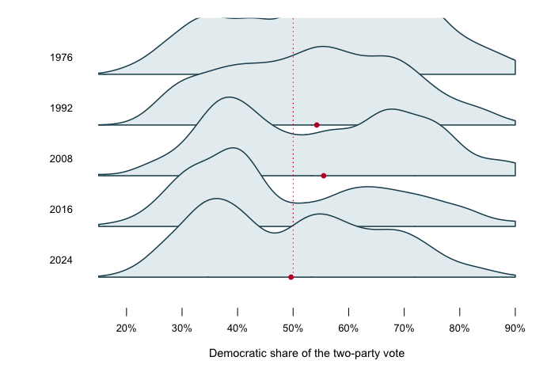

**Figure 4. Five elections, same bandwidth, same axis.** Each year is drawn as a density curve, a smoothed histogram, and the bandwidth is how much smoothing was applied — the curve’s equivalent of a bin width, held the same for every year. The dashed line is an even split and the red dot is that year’s median. Hover a band for its counts.

## What this brief cannot tell you

**It cannot show you the least competitive seats at all.** The 38 uncontested seats of 2024 have no two-party share, so they are absent from every figure above. The valley would be no shallower with them; the flanks would be taller.

**It cannot name an honest form.** The boxplot’s quartiles — the 25th and 75th percentiles that bound its box — are correct. The histogram is correct at every bin width, and the density curves in Figure 4 use one bandwidth chosen once and applied everywhere, which is a defensible choice and still a choice. The argument is not that some charts deceive and others do not. It is that **every summary is a choice about what to discard**, and the only defence is to draw more than one and say which you chose.

**A share is not a seat.** Nothing here counts who won. A district at 49% elected a Republican and a district at 51% elected a Democrat, and this brief has treated them as neighbouring numbers, which they are, and as similar outcomes, which they are not.

## Extensions

None of these is answered above, and every one can be answered from the tables the Sources section hands over.

- `by_year.csv` has `mean` and `median` for every year alongside `sd`. Find the years where mean and median are furthest apart. What is the distribution doing there?
- `by_year.csv` also counts `uncontested` seats. Follow that column across the series. When was the ballot emptiest, and does it move with the `within5` column or against it?
- `by_year.csv` carries `within5` and `within10`. Follow them from 1946 to 2024. Has the number of genuinely close districts fallen, and by how much?
- `districts.csv` is one row per district per year, with the share in `dv`. Pick a year this brief does not draw and build its histogram in a spreadsheet. Then say what that year’s mean was hiding.

Two stretch ideas point past the spreadsheet. Senate races have the same two-party share and only 33-odd contests per cycle; pull one year’s results from the Clerk’s *Statistics* and see whether so few races can even have a valley. And find a published news chart of “average district partisanship” and work out which of the four forms above it silently chose.

## Sources

**Data**

- Jacobson, Gary C. *House Elections Data, 1946–2014.* Democratic share of the two-party vote, by district and year. Circulated privately among researchers; it has no public address, and obtaining it means asking.
- Clerk of the U.S. House of Representatives. *Statistics of the Congressional Election*, 2016 through 2024 editions. https://clerk.house.gov/Votes/ElectionStatistics, with the earlier volumes served by the Office of the Historian at https://history.house.gov/Institution/Election-Statistics/Election-Statistics/
- Both are read through this book’s house-competition chapter, which assembles them and documents its repairs.

**Academic literature**

**The data itself**

Every figure above is drawn from these tables. They are plain CSV, they open in a spreadsheet, and they are yours to take further.

`by_year.csv`, `districts.csv`

One more file is not data about the subject – it is how this chapter checked its own numbers: `facts.csv`, the individual numbers the text above quotes.

[^1]: David R. Mayhew, “Congressional Elections: The Case of the Vanishing Marginals,” *Polity* 6, no. 3 (1974): 295–317, https://www.jstor.org/stable/3233931.